# Forecasting Air Passenger Traffic Using Exponential Smoothing Methods

Sean Schilk

11/30/25

# 1 Introduction

Exponential smoothing methods are a way to forecast future values by looking at past data, giving more importance to recent observations and less to older ones. This helps the model focus on the latest trends while still considering the overall history of the data. How much weight is given to recent versus older data is controlled by parameters in the model, which adjust depending on whether the data shows trends or seasonal patterns.

# 2 Data and Variable Description

I use a dateset provided by R that records monthly Airline passengers, with data recorded from 1949 to 1960. I want to compare various models.

```r
#find a time series with both trend and seasonality. The sample size must be bigger than 100
# Create AirPassengers time series
airP <- ts(AirPassengers, frequency = 12, start = c(1949, 1))
#train the smoothing model
test.air = airP[133:144]
train.air = airP[1:132]
air=ts(airP[1:132], start=2000, frequency = 12)
fit1 = ses(air, h=12)
fit2 = holt(air, initial="optimal", h=12)             ## optimal alpha and beta
fit3 = holt(air,damped=TRUE, h=12 )                   ## additive damping
fit4 = holt(air,exponential=TRUE, damped=TRUE, h =12) ## multiplicative damp
fit5 = hw(air,h=12, seasonal="additive")              ## default h = 10
fit6 = hw(air,h=12, seasonal="multiplicative")
fit7 = hw(air,h=12, seasonal="additive",damped=TRUE)
fit8 = hw(air,h=12, seasonal="multiplicative",damped=TRUE)
```

We also start training the smoothing model here.

# 3 Reporting Accuracy

```r
#Report the accuracy measures
accuracy.table = round(rbind(accuracy(fit1), accuracy(fit2), accuracy(fit3), accuracy(fit4),
                             accuracy(fit5), accuracy(fit6), accuracy(fit7), accuracy(fit8)),4)
row.names(accuracy.table)=c("SES","Holt Linear","Holt Add. Damped", "Holt Exp. Damped",
                            "HW Add.","HW Exp.","HW Add. Damp", "HW Exp. Damp")
kable(accuracy.table, caption = "The accuracy measures of various exponential smoothing models
      based on the training data")
```

The accuracy measures of various exponential smoothing models based on the training data

|  | ME | RMSE | MAE | MPE | MAPE | MASE | ACF1 |
| --- | --- | --- | --- | --- | --- | --- | --- |
| SES | 2.2198 | 31.2141 | 23.9023 | 0.4136 | 8.9118 | 0.7850 | 0.2863 |
| Holt Linear | 0.0690 | 31.1517 | 23.8295 | -0.5842 | 8.9654 | 0.7826 | 0.2861 |
| Holt Add. Damped | 1.4895 | 31.1885 | 23.9315 | -0.0254 | 8.9690 | 0.7859 | 0.2860 |
| Holt Exp. Damped | 1.4063 | 31.2089 | 23.9544 | -0.0447 | 8.9841 | 0.7867 | 0.2858 |
| HW Add. | 0.7468 | 15.4108 | 11.5720 | 0.2590 | 5.0023 | 0.3800 | 0.1636 |
| HW Exp. | 1.3694 | 9.9499 | 7.5333 | 0.2993 | 2.9978 | 0.2474 | 0.3048 |
| HW Add. Damp | 1.6383 | 15.5079 | 11.6708 | 0.6132 | 5.0631 | 0.3833 | 0.1705 |
| HW Exp. Damp | 1.4315 | 8.4823 | 6.7641 | 0.4725 | 2.8575 | 0.2221 | -0.0371 |

Based on the training accuracy measures, the Holt–Winters multiplicative damped model (HW Exp. Damp) is the most appropriate, with HW exp coming in a very close second. HW exp damp produces the lowest RMSE, MAE, MAPE, and MASE values among all models, and its residual ACF1 is closest to zero, indicating that it captures the multiplicative trend and seasonality in the AirPassengers data better than the alternatives.

# 4 Model Building

When we want to forecast future values, we need models that can capture the patterns in the data. Different types of exponential smoothing models are designed for different patterns

We fit 3 types of smoothing models: - simple exponential model, It looks at past values and gives more weight to recent observations to make predictions. - Holt models, Holt’s models can also include a damping feature, which prevents forecasts from projecting trends too aggressively into the future - Holt-Winter’s models, These are used when the data is like monthly sales that rise and fall each year. It keeps long-term forecasts reasonable.

By fitting all three types, we can see which model best matches the behavior of the data and provides the most accurate forecasts. This approach ensures our predictions are reliable and take into account the different patterns that might exist in the data.

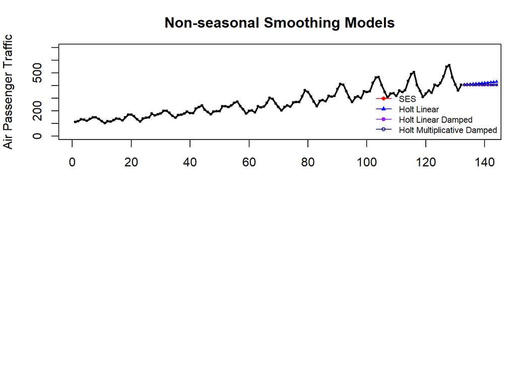

```r
#fit three types of smoothing models
par(mfrow=c(2,1), mar=c(3,4,3,1))
###### plot the original data
pred.id = 133:144
plot(1:132, train.air, lwd=2,type="o", ylab="Air Passenger Traffic", xlab="",
     xlim=c(1,140), ylim=c(0, 700), cex=0.3,
     main="Non-seasonal Smoothing Models")
lines(pred.id, fit1$mean, col="red")
lines(pred.id, fit2$mean, col="blue")
lines(pred.id, fit3$mean, col="purple")
lines(pred.id, fit4$mean, col="navy")
points(pred.id, fit1$mean, pch=16, col="red", cex = 0.5)
points(pred.id, fit2$mean, pch=17, col="blue", cex = 0.5)
points(pred.id, fit3$mean, pch=19, col="purple", cex = 0.5)
points(pred.id, fit4$mean, pch=21, col="navy", cex = 0.5)
#points(fit0, col="black", pch=1)
legend("bottomright", lty=1, col=c("red","blue","purple", "navy"),pch=c(16,17,19,21),
   c("SES","Holt Linear","Holt Linear Damped", "Holt Multiplicative Damped"),
   cex = 0.7, bty="n")
```

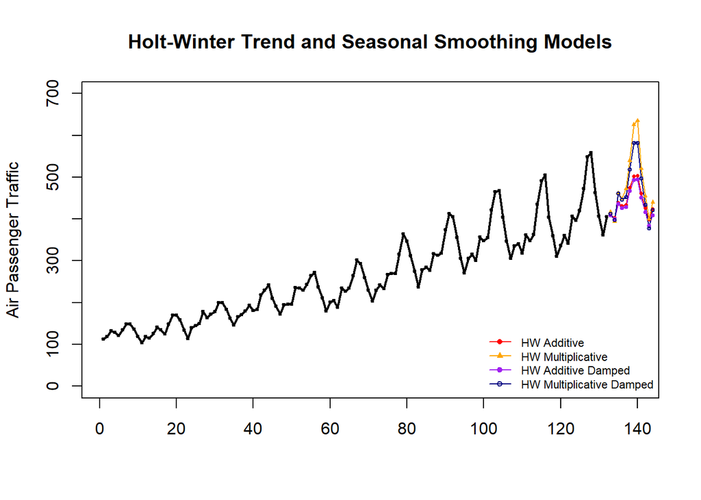

```r
plot(1:132, train.air, lwd=2,type="o", ylab="Air Passenger Traffic", xlab="",
     xlim=c(1,140), ylim=c(0, 700), cex=0.3,
     main="Holt-Winter Trend and Seasonal Smoothing Models")
lines(pred.id, fit5$mean, col="red")
lines(pred.id, fit6$mean, col="orange")
lines(pred.id, fit7$mean, col="purple")
lines(pred.id, fit8$mean, col="navy")
points(pred.id, fit5$mean, pch=16, col="red", cex = 0.5)
points(pred.id, fit6$mean, pch=17, col="orange", cex = 0.5)
points(pred.id, fit7$mean, pch=19, col="purple", cex = 0.5)
points(pred.id, fit8$mean, pch=21, col="navy", cex = 0.5)
###
legend("bottomright", lty=1, col=c("red","orange","purple", "navy"),pch=c(16,17,19,21),
   c("HW Additive","HW Multiplicative","HW Additive Damped", "HW Multiplicative Damped"),
   cex = 0.7, bty="n")
```

# 5 Forecasting

To use the model for real-forecast, we need to refit the model using the entire data to update the smoothing parameters in the final working model.

```r
#forecast errors based on the holp-up test data
acc.fun = function(test.data, mod.obj){
  PE=100*(test.data-mod.obj$mean)/mod.obj$mean
  MAPE = mean(abs(PE))
  ###
  E=test.data-mod.obj$mean
  MSE=mean(E^2)
  ###
  accuracy.metric=c(MSE=MSE, MAPE=MAPE)
  accuracy.metric
}
pred.accuracy = rbind(SES =acc.fun(test.data=test.air, mod.obj=fit1),
                      Holt.Add =acc.fun(test.data=test.air, mod.obj=fit2),
                      Holt.Add.Damp =acc.fun(test.data=test.air, mod.obj=fit3),
                      Holt.Exp =acc.fun(test.data=test.air, mod.obj=fit4),
                      HW.Add =acc.fun(test.data=test.air, mod.obj=fit5),
                      HW.Exp =acc.fun(test.data=test.air, mod.obj=fit6),
                      HW.Add.Damp =acc.fun(test.data=test.air, mod.obj=fit7),
                      HW.Exp.Damp =acc.fun(test.data=test.air, mod.obj=fit8))
kable(pred.accuracy, caption="The accuracy measures of various exponential smoothing models
      based on the testing data")
```

The accuracy measures of various exponential smoothing models based on the testing data

|  | MSE | MAPE |
| --- | --- | --- |
| SES | 10604.7788 | 18.766339 |
| Holt.Add | 8704.9008 | 15.951858 |
| Holt.Add.Damp | 10470.8899 | 18.582241 |
| Holt.Exp | 10402.9608 | 18.488347 |
| HW.Add | 2894.0839 | 8.672744 |
| HW.Exp | 274.9997 | 2.259376 |
| HW.Add.Damp | 3582.8358 | 10.052207 |
| HW.Exp.Damp | 501.8367 | 3.994461 |

# 6 Final Model

Now we need to refit the model at the very end using the entire data to update the smoothing parameters in the final working model.

```r
#Make a serial plot of the historical data (training data) and forecast values
final.model = hw(airP,h=12, seasonal="multiplicative", damped = TRUE)
smoothing.parameter = final.model$model$par[1:3]
kable(smoothing.parameter, caption="Estimated values of the smoothing parameters in
      Holt–Winters multiplicative damped model")
```

Estimated values of the smoothing parameters in Holt–Winters multiplicative damped model

|  | x |
| --- | --- |
| alpha | 0.7194000 |
| beta | 0.0568436 |
| gamma | 0.0001000 |

The table above shows the estimated smoothing parameters for the Holt-Winters multiplicative damped model. These parameters control how the model reacts to recent changes in the data:

- **Alpha** (α = 0.72) determines how much weight the model gives to the most recent observation when updating the level of the series. A higher value means the model reacts more quickly to recent changes.
- **Beta** (β = 0.057) controls how quickly the trend is updated. The relatively low value shows that the trend is adjusted gradually over time.
- **Gamma** (γ = 0.0001) controls the seasonal component. The very small value indicates that seasonal adjustments are relatively stable, meaning the model relies more on the underlying trend than on abrupt seasonal shifts.

Overall, these parameters allow the model to produce forecasts that are responsive to recent trends while maintaining stable seasonal patterns, providing reliable predictions for future values.